# Reproducible Research: Peer Assessment 2

Mostafa Alaa

10 Jan 2016

## Synonpsis

In this report, we will analyze the impact of different events and which of these events are most harmful with respect to population health and economy problems for communities and municipalities based on the U.S. National Oceanic and Atmospheric Administration’s (NOAA) storm database. The major estmate we will use is the We will use the estimates of fatalities, injuries, and property damage, and preventing such outcomes to decide which types of event are most harmful to the population health and economy. After our analysis we found that excessive heat and tornado are most harmful with respect to population health, while flood, drought, and hurricane/typhoon have the greatest economic consequences.

## Documents settings

```r
echo = TRUE  # For All the document make code visible
locale_original <- Sys.getlocale( category = "LC_TIME" )
Sys.setlocale("LC_TIME", "English")
```

```
## [1] "English_United States.1252"
```

```r
options(scipen = 1)  # Turn off scientific notations for numbers
```

## Load Needed Libraries

```r
library(ggplot2)
library(plyr)
library(lattice)
library(sqldf)
library(R.utils)
library(gridExtra)
```

## Data Processing

1. Download the data

```r
setwd("E:/Learning/Master/Data Science/Reproducible Research/Project 2") #Set the project directory path

#check data exists #if no download

if (!"repdata_data_StormData.csv.bz2" %in% dir("./NOAADataSet/"))
        {
                download.file("http://d396qusza40orc.cloudfront.net/repdata%2Fdata%2FStormData.csv.bz2", destfile = "NOAADataSet/repdata_data_StormData.csv.bz2")
        }
```

2. Extract Zipped file

```r
#check if the file extracted before don't extract again
  if (!"repdata_data_StormData.csv" %in% dir("./NOAADataSet/")) {
              bunzip2("NOAADataSet/repdata_data_StormData.csv.bz2", overwrite=T, remove=F)
}
```

3.Load the Data from File

```r
#check if the file exist in the working environment don't load it again due to the huge size
if (!"stormDS" %in% ls()) {
    stormDS <- read.csv("NOAADataSet/repdata_data_StormData.csv", sep = ",")
}

head(stormDS, n = 2)
```

```
##   STATE__          BGN_DATE BGN_TIME TIME_ZONE COUNTY COUNTYNAME STATE
## 1       1 4/18/1950 0:00:00     0130       CST     97     MOBILE    AL
## 2       1 4/18/1950 0:00:00     0145       CST      3    BALDWIN    AL
##    EVTYPE BGN_RANGE BGN_AZI BGN_LOCATI END_DATE END_TIME COUNTY_END
## 1 TORNADO         0                                               0
## 2 TORNADO         0                                               0
##   COUNTYENDN END_RANGE END_AZI END_LOCATI LENGTH WIDTH F MAG FATALITIES
## 1         NA         0                        14   100 3   0          0
## 2         NA         0                         2   150 2   0          0
##   INJURIES PROPDMG PROPDMGEXP CROPDMG CROPDMGEXP WFO STATEOFFIC ZONENAMES
## 1       15    25.0          K       0
## 2        0     2.5          K       0
##   LATITUDE LONGITUDE LATITUDE_E LONGITUDE_ REMARKS REFNUM
## 1     3040      8812       3051       8806              1
## 2     3042      8755          0          0              2
```

```r
# subset the data to health and economic impact analysis against weather
# event
```

We can figure out the data dim 902297 rows and 37 columns in total. Events from 1950:2011 . In the first years of the database there there are fewer events recorded if we compare with the most recent years should be considered more complete Most likely due to the data was not completed. Let’s view the data.

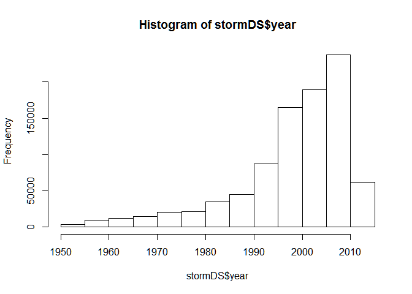

```r
    stormDS$year <- as.numeric(format(as.Date(stormDS$BGN_DATE, format = "%m/%d/%Y %H:%M:%S"), "%Y"))

hist(stormDS$year, breaks = 20)
```

4. Data Cleansing and Preparation

in this section we will make two main data manipulation A. Get the Subset column of the data which we are interested in. B. Column handle: is aimed to convert the property damage and crop damage data into comparable numerical forms according to the meaning of units described in the code book for each observation where we have Hundred (H), Thousand (K), Million (M) and Billion (B).

```r
mycol_interest <- c("EVTYPE", "FATALITIES", "INJURIES", "PROPDMG", "PROPDMGEXP", "CROPDMG",
    "CROPDMGEXP")
storm <- stormDS[mycol_interest]

# exploring the property exponent
unique(storm$PROPDMGEXP)
```

```
##  [1] K M   B m + 0 5 6 ? 4 2 3 h 7 H - 1 8
## Levels:  - ? + 0 1 2 3 4 5 6 7 8 B h H K m M
```

```r
# exploring the crop exponent data
unique(storm$CROPDMGEXP)
```

```
## [1]   M K m B ? 0 k 2
## Levels:  ? 0 2 B k K m M
```

```r
colHandler <- function(dataset = storm, fieldName, newFieldName) {
    totalLen <- dim(dataset)[2]
    index <- which(colnames(dataset) == fieldName)
    dataset[, index] <- as.character(dataset[, index])
    logic <- !is.na(toupper(dataset[, index]))
    dataset[logic & toupper(dataset[, index]) == "B", index] <- "9"
    dataset[logic & toupper(dataset[, index]) == "M", index] <- "6"
    dataset[logic & toupper(dataset[, index]) == "K", index] <- "3"
    dataset[logic & toupper(dataset[, index]) == "H", index] <- "2"
    dataset[logic & toupper(dataset[, index]) == "", index] <- "0"
    dataset[, index] <- as.numeric(dataset[, index])
    dataset[is.na(dataset[, index]), index] <- 0
    dataset <- cbind(dataset, dataset[, index - 1] * 10^dataset[, index])
    names(dataset)[totalLen + 1] <- newFieldName
    return(dataset)
}

storm <- colHandler(storm, "PROPDMGEXP", "PROPDMGE")
storm <- colHandler(storm, "CROPDMGEXP", "CROPDMGE")
```

## Impact on Public Health

In this section, we will check the number of fatalities and injuries that are happened by Event Type. We will get the top 10 severe for each one.

```r
fatalities  <- sqldf("select EVTYPE, SUM(FATALITIES) FATALITIES from storm group by EVTYPE order by FATALITIES DESC LIMIT 10",row.names = TRUE)


injury  <- sqldf("select EVTYPE, SUM(INJURIES) INJURIES from storm group by EVTYPE order by INJURIES DESC LIMIT 10",row.names = TRUE)
```

## Impact on Economy

The two major column that impact into the economy is the PROPDMGE and CROPDMGE

```r
proddmge  <- sqldf("select EVTYPE, SUM(PROPDMGE) PROPDMGE from storm group by EVTYPE order by PROPDMGE DESC LIMIT 10",row.names = TRUE)


cropdmge  <- sqldf("select EVTYPE, SUM(CROPDMGE) CROPDMGE from storm group by EVTYPE order by CROPDMGE DESC LIMIT 10",row.names = TRUE)
```

## Results

Aross the United States, Which types of events are nost harmful with respect to population health?

```r
fatalities
```

```
##            EVTYPE FATALITIES
## 1         TORNADO       5633
## 2  EXCESSIVE HEAT       1903
## 3     FLASH FLOOD        978
## 4            HEAT        937
## 5       LIGHTNING        816
## 6       TSTM WIND        504
## 7           FLOOD        470
## 8     RIP CURRENT        368
## 9       HIGH WIND        248
## 10      AVALANCHE        224
```

```r
injury
```

```
##               EVTYPE INJURIES
## 1            TORNADO    91346
## 2          TSTM WIND     6957
## 3              FLOOD     6789
## 4     EXCESSIVE HEAT     6525
## 5          LIGHTNING     5230
## 6               HEAT     2100
## 7          ICE STORM     1975
## 8        FLASH FLOOD     1777
## 9  THUNDERSTORM WIND     1488
## 10              HAIL     1361
```

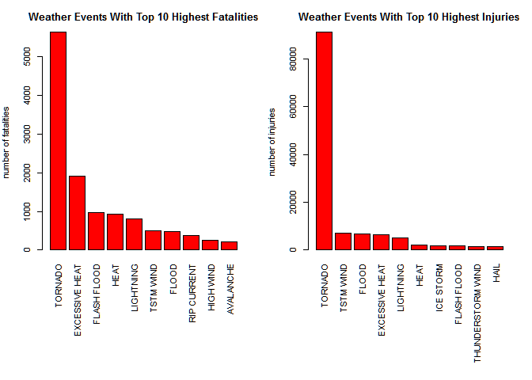

```r
par(mfrow = c(1, 2), mar = c(12, 4, 3, 2), mgp = c(3, 1, 0), cex = 0.7)
barplot(fatalities$FATALITIES, las = 3, names.arg = fatalities$EVTYPE, main = "Weather Events With Top 10 Highest Fatalities",
    ylab = "number of fatalities", col = "red")
barplot(injury$INJURIES, las = 3, names.arg = injury$EVTYPE, main = "Weather Events With Top 10 Highest Injuries",
    ylab = "number of injuries", col = "red")
```

With looking in the figure we can for sure say that: The most harmful weather event to population health is Tornado.It is cause for both the highest fatalities and the highest injuries across United States.

## Across the United States, which types of events have the greatest economic consequences?

```r
proddmge
```

```
##               EVTYPE     PROPDMGE
## 1              FLOOD 144657709807
## 2  HURRICANE/TYPHOON  69305840000
## 3            TORNADO  56947380677
## 4        STORM SURGE  43323536000
## 5        FLASH FLOOD  16822673979
## 6               HAIL  15735267513
## 7          HURRICANE  11868319010
## 8     TROPICAL STORM   7703890550
## 9       WINTER STORM   6688497251
## 10         HIGH WIND   5270046295
```

```r
cropdmge
```

```
##               EVTYPE    CROPDMGE
## 1            DROUGHT 13972566000
## 2              FLOOD  5661968450
## 3        RIVER FLOOD  5029459000
## 4          ICE STORM  5022113500
## 5               HAIL  3025954473
## 6          HURRICANE  2741910000
## 7  HURRICANE/TYPHOON  2607872800
## 8        FLASH FLOOD  1421317100
## 9       EXTREME COLD  1292973000
## 10      FROST/FREEZE  1094086000
```

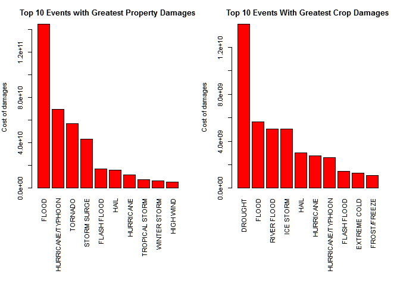

```r
par(mfrow = c(1, 2), mar = c(12, 4, 3, 2), mgp = c(3, 1, 0), cex = 0.7)
barplot(proddmge$PROPDMGE, las = 3, names.arg = proddmge$EVTYPE,
    main = "Top 10 Events with Greatest Property Damages", ylab = "Cost of damages",
    col = "red")
barplot(cropdmge$CROPDMGE, las = 3, names.arg = cropdmge$EVTYPE,
    main = "Top 10 Events With Greatest Crop Damages", ylab = "Cost of damages",
    col = "red")
```

The weather events that have the greatest economic consequences are: flood, drought, Tornado and Typhoon.

## Conclusion

From these data, we found that tornado and excessive heat are most harmful with respect to population health, while flood, drought, and hurricane/typhoon have the greatest economic consequences. I think we must start with tornado due to its harmful for both side health and economy.